# Chapter11_HW

Lin Zhang

11/2/2019

# 10E1. If an event has probability 0.35, what are the log-odds of this event?

```r
log(0.35/(1-0.35))
```

```
## [1] -0.6190392
```

```r
logit(.35)
```

```
## [1] -0.6190392
```

# 10E2. If an event has log-odds 3.2, what is the probability of this event?

```r
inv_logit(3.2)
```

```
## [1] 0.9608343
```

```r
exp(3.2)/(1+exp(3.2))
```

```
## [1] 0.9608343
```

#10M1. As explained in the chapter, binomial data can be organized in aggregated and disaggregated forms, without any impact on inference. But the likelihood of the data does change when the data are converted between the two formats. Can you explain why? ?? extra parameter, extra factor

# Week6_Problem_1 NWO fund

```r
data("NWOGrants")
d <- NWOGrants
str(d)
```

```
## 'data.frame':    18 obs. of  4 variables:
##  $ discipline  : Factor w/ 9 levels "Chemical sciences",..: 1 1 6 6 7 7 3 3 9 9 ...
##  $ gender      : Factor w/ 2 levels "f","m": 2 1 2 1 2 1 2 1 2 1 ...
##  $ applications: int  83 39 135 39 67 9 230 166 189 62 ...
##  $ awards      : int  22 10 26 9 18 2 33 32 30 13 ...
```

```r
#build model for total effect of gender on grant awards
d$gid <- ifelse(d$gender=="m",1,2)
m1.1 <- quap(
  alist(
    awards ~ dbinom(applications,p),
    logit(p) <- a[gid],
    a[gid] ~ dnorm(0,1.5)
    ),data = d
  )
precis(m1.1,depth = 2)
```

```
##           mean         sd      5.5%     94.5%
## a[1] -1.531418 0.06462435 -1.634700 -1.428136
## a[2] -1.737428 0.08121368 -1.867223 -1.607633
```

```r
#compute contrast on the logit scale relative and outcome scale absolute
post <- extract.samples(m1.1)
diff_a <- post$a[,1]-post$a[,2]
diff_p <- inv_logit(post$a[,1])-inv_logit(post$a[,2])
precis(list(diff_a=diff_a,diff_p=diff_p))
```

```
##              mean         sd        5.5%      94.5%
## diff_a 0.20341300 0.10351755 0.037063076 0.36868710
## diff_p 0.02767297 0.01397465 0.005126048 0.04960957
##                                                                                       histogram
## diff_a                         ▁▁▂▇▇▃▁▁
## diff_p ▁▁▁▂▅▇▇▃▁▁▁
```

```r
# in general, across discipline, male is 0.03 higher in probablity space to get awarded
```

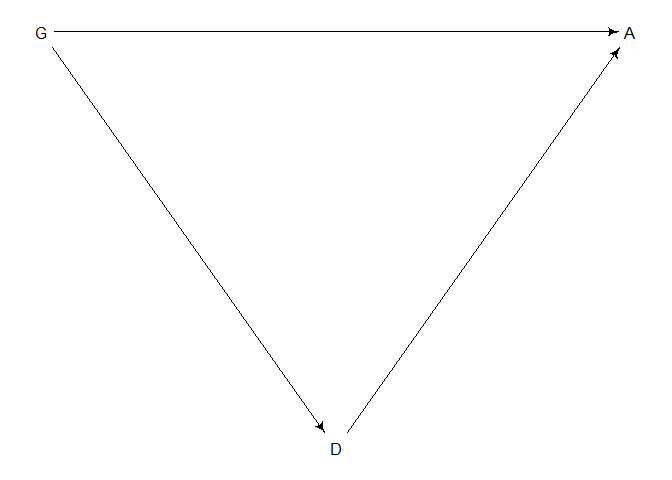

```r
library(dagitty)
dag1 <- dagitty("dag{
                G->D
                D->A
                G->A
                }"
)
coordinates(dag1) <- list(x=c(G=0,D=1,A=2),y=c(G=0,A=0,D=1))
drawdag(dag1)
```

```r
#build model for total effect of gender on grant awards
d$dis_id <- rep(1:9,each=2)
m1.2 <- quap(
  alist(
    awards ~ dbinom(applications,p),
    logit(p) <- a[gid]+delta[dis_id],
    a[gid] ~ dnorm(0,1.5),
    delta[dis_id] ~ dnorm(0,1.5)
  ),data = d
)
precis(m1.2,depth = 2)
```

```
##                mean        sd       5.5%      94.5%
## a[1]     -1.1578401 0.4565098 -1.8874309 -0.4282494
## a[2]     -1.2955002 0.4597880 -2.0303302 -0.5606702
## delta[1]  0.1637017 0.4908967 -0.6208461  0.9482495
## delta[2] -0.1884150 0.4856753 -0.9646180  0.5877880
## delta[3]  0.1398275 0.5114927 -0.6776366  0.9572916
## delta[4] -0.4103747 0.4709093 -1.1629787  0.3422293
## delta[5] -0.3809051 0.4792306 -1.1468082  0.3849980
## delta[6] -0.4466022 0.4895118 -1.2289366  0.3357321
## delta[7] -0.1755191 0.4742532 -0.9334674  0.5824292
## delta[8] -0.6369930 0.4640407 -1.3786196  0.1046336
## delta[9] -0.5156652 0.4687250 -1.2647782  0.2334478
```

```r
post <- extract.samples(m1.2)
diff_a <- post$a[,1]-post$a[,2]
diff_p <- inv_logit(post$a[,1])-inv_logit(post$a[,2])
precis(list(diff_a=diff_a,diff_p=diff_p))
```

```
##              mean         sd         5.5%      94.5%
## diff_a 0.13835626 0.10746815 -0.033225672 0.30895199
## diff_p 0.02399182 0.01982271 -0.005678494 0.05640977
##                                                                       histogram
## diff_a ▁▁▂▅▇▅▁▁▁
## diff_p ▁▁▂▇▇▃▁▁▁
```

```r
# condition on  discipline, male is 0.02 higher in probablity space to get awarded
```

# Consider an unobserved confound

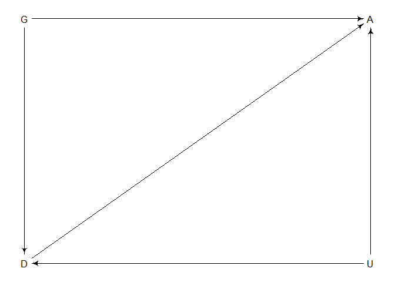

```r
library(dagitty)
dag1 <- dagitty("dag{
                G->D
                D->A
                G->A
                U->D
                U->A
                }"
)
coordinates(dag1) <- list(x=c(G=0,D=0,A=1,U=1),y=c(G=0,A=0,D=1,U=1))
drawdag(dag1)
```

```r
# conditional on discipline causes gender and unobserved confound(such as career stages) to be correlated, the collider is open
# it does not provide an un-confounded estimate of the direct path from gender to an award, as the backdoor is open through the unobserved confound
# simulate?
# but for a regression conditioning on both gender adn discipline to suggest zero influence??
```

# Chapter 11.2 problems

##10E4. Why do Poisson regressions sometimes require the use of an offset? Provide an example.

```r
# Possion regressions reflect count of an event over a fixed interval, sometimes two datasets have different intervals, this would require a offset. The example in the textbook as in the monastery, whether production is counted per day or per week. Other examples include recombination event across genome, per 100kb or per 1MB, as well as SNP density.
```

## 10M2.

If a coefficient in a Poisson regression has value 1.7, what does this imply about the change in the outcome?

```r
# for every unit change in the predictor there will be a 5.47-fold (e^1.7) increase in the number of counts
# a^n*a^m=a^(n+m)
# exp(a+1.7(x+1)) = exp(1.7)exp(a+1.7x)
exp(1.7)
```

```
## [1] 5.473947
```

## 10M3.

Explain why the logit link is appropriate for a binomial generalized linear model.

```r
# binomial generalized linear model uses a binomial distribution to model count in a binary option with the parameter being probability of one option in each single trial, logit link would transfer a linear model to a probability scale and constrain the parameter between 0 and 1
```

## 10M4.

Explain why the log link is appropriate for a Poisson generalized linear model.

```r
#Poisson generalized linear model use Poisson distribution to model count within a fixed interval with low rate, the count has no upper limit.
# a log link map linear model to positive reals
```

# Chapter 11.3 problems

##10H3 The data contained in library(MASS);data(eagles) are records of salmon pirating attempts by Bald Eagles in Washington State. See ?eagles for details. While one eagle feeds, sometimes another will swoop in and try to steal the salmon from it. Call the feeding eagle the “victim” and the thief the “pirate.” Use the available data to build a binomial GLM of successful pirating attempts.

```r
library(rethinking)
library(MASS)
data("eagles")
d <- eagles
```

```r
summary(is.na(d))
```

```
##      y               n               P               A
##  Mode :logical   Mode :logical   Mode :logical   Mode :logical
##  FALSE:8         FALSE:8         FALSE:8         FALSE:8
##      V
##  Mode :logical
##  FALSE:8
```

```r
d$Aid <- as.numeric(ifelse(d$A=="A",1,0))
d$Pid <- as.numeric(ifelse(d$P=="L",1,0))
d$Vid <- as.numeric(ifelse(d$V=="L",1,0))
```